# Ecology of the Thymus

Mary Browning, John Wares, Nancy Manley

10 December, 2014

## Introduction

The co-distribution of constituent species in a community is often used to indicate interaction - whether competitive, trophic, or facilitative (Verberk 2011; Angelini et al. 2011). By analyzing the exact spatial location and co-location of component cell types across the domain of a particular tissue or organ, we may gain a better understanding of which interactions - indicated by codistribution and sufficient density - can be validated by independent approach and analysis. To an extent, we recapitulate the spatial scales described above: we explore the differentiation of distinct habitats within the environment (biogeography: identifying regions of endemicity or dramatically shifted abundance), the colocalization of particular sub-groups of cells (community ecology), and we use the tenets of macroecology to the extent that we can generalize that cells need a particular density to be viable interactors, and to the extent that common cells have a larger overall distribution (this is not tautological, this follows from the first: you cannot be rare and widespread in a functional sense). Our overall goal is development of a cellular ecology, where we can understand interactions at a quantitative level that does not yet exist in developmental biology, particularly in this system. We seek to create a map of a healthy adult organ using cell location and abundance, and then to spatially characterize the organ by applying ecological theory directly to the produced map (something that has never been done before). The results from this analysis can be used to make comparisons with organs in states of disequilibrium, such as diseased or mutant organs, in order to see what organizational differences occur.

We performed this analysis on our model organ, the thymus. The thymus was chosen because it is an intriguing example of cellular level organization, with a strong connection between organization and function. The thymus consists of developing T cells supported by a complex cellular environment containing a variety of resident cell types, including thymic epithelial cells (TECs), dendritic cells, vasculature, and mesenchymal cells. These cell types comprise multiple microenvironments that direct and support thymocytes to develop from immature progenitors into mature T cells that are both self-tolerant and self-restricted. T cell development in the thymus requires interactions with the thymic microenvironments that provide signals for their survival, proliferation, and differentiation [1]. Despite their critical role in the generation of cellular immunity and the clinical importance of thymic regeneration, the composition and organization of thymic microenvironments and the mechanisms that promote their proper development and function are not fully understood, in part due to a lack of technical and theoretical approaches for quantifying tissue-level properties. Thus, the thymus has many characteristics that make it an excellent system for developing and testing quantitative modeling: a diverse cellular composition that can be identified with cell type-specific markers, regional organization that is required for maximal organ function, genetic models with diverse effects on organ composition and function, assays for experimentally inducing organ degeneration and regeneration, and high biomedical relevance. To date, there are no quantitative models of thymus organ structure and function and no established methods for generating one. We seek to address this by developing a quantitative theoretical model of the organization of cell types that can be used to better understand thymic function as well as evaluate diseased states. Our approach uses immunostaining on sagittal serial sections of a wildtype mouse thymus in order to identify distinct cellular subsets, followed by the use of novel computational approaches in order to quantitatively identify known and cryptic cellular spatial relationships. We then take this approach one step further by comparing a wildtype and a mutant (Aire knockout) mouse thymus in an effort to identify differences in organizational characteristics.

## Methods

### Terminology

I suggest an explanatory box for readers so that quadrat, section, composite, etc. can all be explained clearly in one place.

| quadrat | spatial | sampled unit within domain; cell types in quadrats used to find regions of similar composition |
| --- | --- | --- |
| transect | spatial | linear array of sampled units (quadrats), may be comprehensively or randomly sampled |
| layer | tissue | actual tissue sample used to assay single-cell thickness composition |

1. Where the mice come from and other necessary information about the Aire mutant line (Mary, Nancy)
2. Information about the antibody stains, the frozen versus paraffin protocols
3. Staining protocol and visualization with Cell Profiler: you need to explain whatever settings/parameters were used to obtain your data files, including how overlapping sections were lined up.
4. Data Transformation
5. Quadrat Selection and Rarefaction: you need to explain how you did this, and the next chunk can include the code you used to achieve this. That way, our results can include one plot and a brief discussion about the selection of that size quadrat and what it means for inclusion of cell types in a given quadrat

Read in datafile generated from CellProfiler (1 cell type per file)

6. Now get into the methods you already have in your R script, first setting K=2 and removing all quadrats that fall outside of the thymus from further analysis. You can do this using the subset command I think. We can then talk about more ways to maintain the identity of a given cluster of spatial quadrats (identity being the type of mouse, the section of thymus, and so on)

CellProfiler outputs X&Y coordinates in an excel file (which also contains other unnecessary info). I delete the unnecessary info and add points ((0,0), (0,X), (X,0), (X,X)) to the X and Y columns in order to make a square so that the bin sizes in the matrix will be a consistent size. I save this file as a .txt. It is now ready to run through my script. The next step is to transform my data from individual .txt files into a community matrix that contains all the cell types. The community matrix is then used for Kmeans clustering. The next step is clustering.

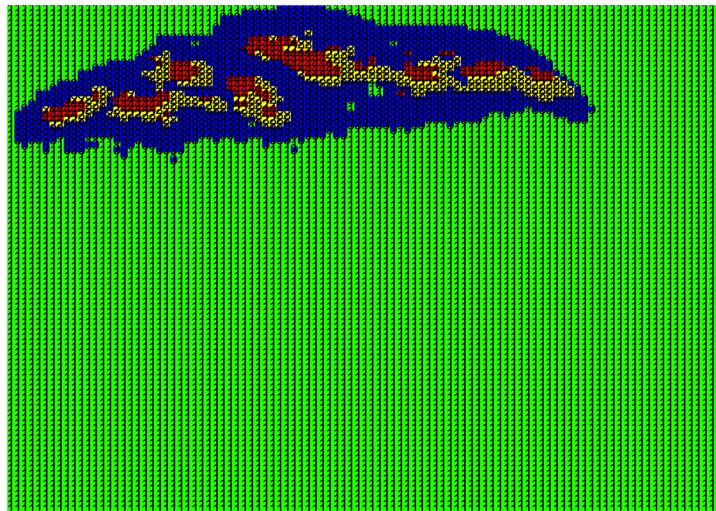

Next Step: Figuring out how clustering is done We can see that we’ve asked R to take cell count info from 11 cell types and make 4 clusters

It turns out that cluster 1 is just *empty* space - but not clusters 2-4 #need automatic way to identify *empty* outside of thymus

We can make a running sum of all the counts of all cell types by cluster

and normalize these so that each cluster type has the same total amount of cells (in other words, we’re getting the proportion of cell types in each cluster)

We can look at the difference between pairs of clusters to see which cell types are most different between clusters

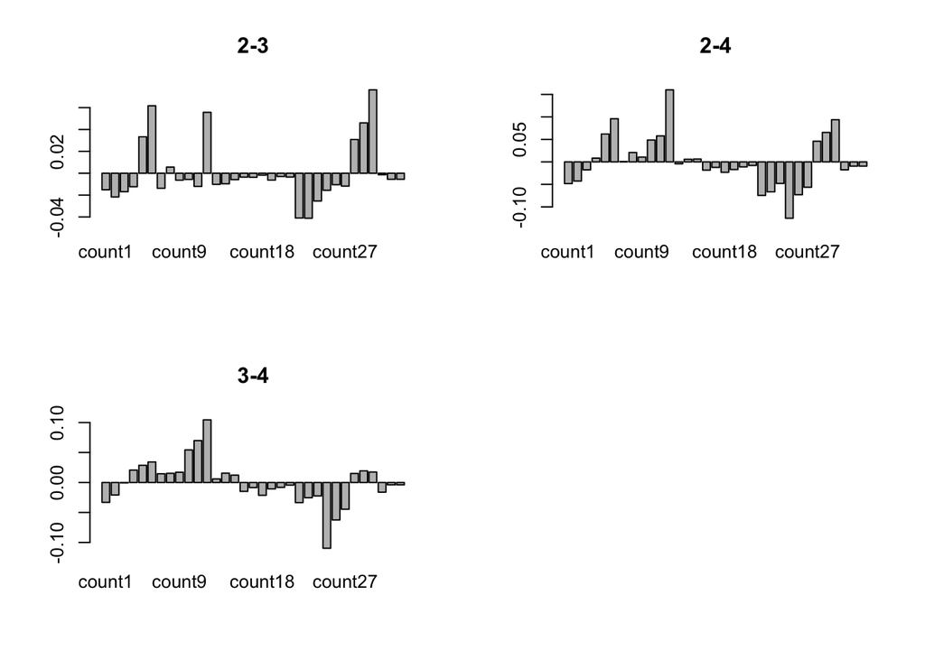

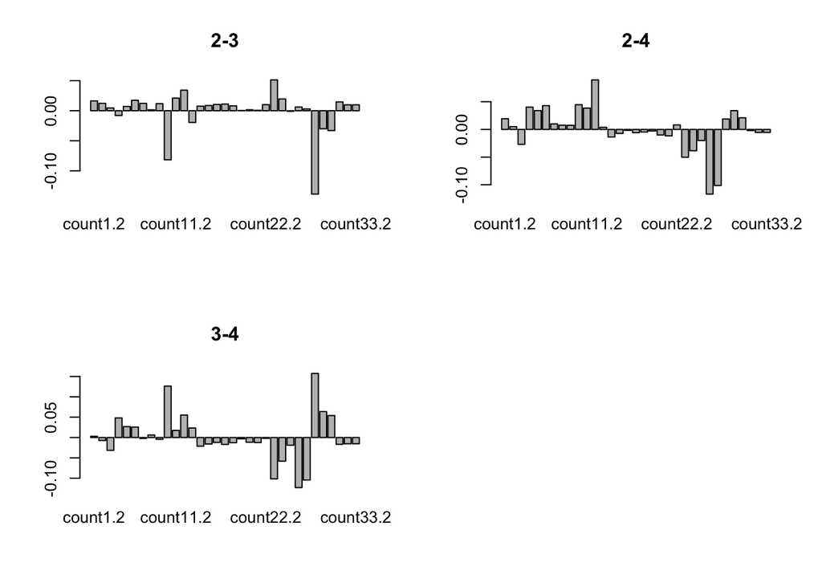

6b. bray curtis

6c. significant diffs between cell types?

7. also Andrew Sornborger’s approach for separating out the geometry/geography of clusters., and/or using connected component labeling to identify size, centroid, distance of centroids among clusters
8. jackknifing : removing one cell type at a time

The way to read the last plots is for something like “2-3”, positive bars mean that cell type is more common in cluster 2 (than 3); negative bars mean the opposite. The higher the absolute number on the y-axis, the greater the difference is in that cell count between the two clusters. I think (as John suggested), that we can move ahead and be more formal with this analysis (e.g. Bray Curtis dissimilarity), but this is a useful first step.

## Mary’s plan for Bray Curtis

In R, the analogy to re-oarganizing data by either pivot tables, or manual calculation and pasting into a new sheet, is to manipulate one data frame to another. The ‘dplyr’ package or the ‘aggregate’ function can both help you here. For most standard ecology metrics there are usually one or more packages that make our life easier. Here the ‘vegan’ package is useful. In this example, we work out Bray-Curtis for all clusters (pairwise comparison)

df<-NULL df2<-NULL #these nulls are here to reset the dataframes from the rbind that is below, only important if iteratign across commands outside of KNITR

```r
library(vegan) # you may need to install this if you don't have it
library(dplyr) # ditto (used for chaining and manipulation)
# http://blog.rstudio.org/2014/01/17/introducing-dplyr/
#df<-spe[which(spe.kmeans$cluster==1),] %>% colSums() %>% t() # example of chaining.
#reads as: take only cluster 1 data from 'spe', then take column sums (i.e. total cell type count)
#then transpose (swap rows/cols needed for bray curtis calc)

# each of these
df<-spe[which(spe.kmeans$cluster==1),] %>% colSums() %>% t()
for (j in 2:4){
  tmp<-spe[which(spe.kmeans$cluster==j),] %>% colSums() %>% t()
  df<-rbind(df,tmp)
}

df1.1<-spe1.1[which(spe.kmeans1.1$cluster==1),] %>% colSums() %>% t()
for (j in 2:4){
  tmp1.1<-spe1.1[which(spe.kmeans1.1$cluster==j),] %>% colSums() %>% t()
  df1.1<-rbind(df1.1,tmp1.1)
}

df1.2<-spe1.2[which(spe.kmeans1.2$cluster==1),] %>% colSums() %>% t()
for (j in 2:4){
  tmp1.2<-spe1.2[which(spe.kmeans1.2$cluster==j),] %>% colSums() %>% t()
  df1.2<-rbind(df1.2,tmp1.2)
}

df1.2<-spe1.2[which(spe.kmeans1.2$cluster==1),] %>% colSums() %>% t()
for (j in 2:4){
  tmp1.2<-spe1.2[which(spe.kmeans1.2$cluster==j),] %>% colSums() %>% t()
  df1.2<-rbind(df1.2,tmp1.2)
}

df2<-spe2[which(spe.kmeans2$cluster==1),] %>% colSums() %>% t()
for (j in 2:4){
  tmp2<-spe2[which(spe.kmeans2$cluster==j),] %>% colSums() %>% t()
  df2<-rbind(df2,tmp2)
}

df2.1<-spe2.1[which(spe.kmeans2.1$cluster==1),] %>% colSums() %>% t()
for (j in 2:4){
  tmp2.1<-spe2.1[which(spe.kmeans2.1$cluster==j),] %>% colSums() %>% t()
  df2.1<-rbind(df2.1,tmp2.1)
}

df2.2<-spe2.2[which(spe.kmeans2.2$cluster==1),] %>% colSums() %>% t()
for (j in 2:4){
  tmp2.2<-spe2.2[which(spe.kmeans2.2$cluster==j),] %>% colSums() %>% t()
  df2.2<-rbind(df2.2,tmp2.2)
}

df2.2<-spe2.2[which(spe.kmeans2.2$cluster==1),] %>% colSums() %>% t()
for (j in 2:4){
  tmp2.2<-spe2.2[which(spe.kmeans2.2$cluster==j),] %>% colSums() %>% t()
  df2.2<-rbind(df2.2,tmp2.2)
}

rownames(df)<-c("cluster1","cluster2","cluster3","cluster4")

df<-apply(df,2,as.integer) %>% as.data.frame()
df1.1<-apply(df1.1,2,as.integer) %>% as.data.frame()
df1.2<-apply(df1.2,2,as.integer) %>% as.data.frame()
df1.2<-apply(df1.2,2,as.integer) %>% as.data.frame()

df2<-apply(df2,2,as.integer) %>% as.data.frame()
df2.1<-apply(df2.1,2,as.integer) %>% as.data.frame()
df2.2<-apply(df2.2,2,as.integer) %>% as.data.frame()
df2.2<-apply(df2.2,2,as.integer) %>% as.data.frame()

#need same number of columns to bind them.
colnames(df2)<-colnames(df)

colnames(df1.1)=colnames(df2.1)
colnames(df1.2)<-colnames(df2.1)
colnames(df1.2)<-colnames(df2.1)
colnames(df2.1)<-colnames(df2.1)
colnames(df2.2)<-colnames(df2.1)
colnames(df2.2)<-colnames(df2.1)
# this is it column names were wrong

dfTOTAL<-rbind(df1.2,df2.2, df1.2, df1.2, df1.1, df1.1)

BrayCurtis<-vegdist(dfTOTAL,method="bray")
print(BrayCurtis)
```

```
            1          2          3          4          5          6
2  0.37024760
3  0.51636778 0.45879273
4  0.88191713 0.81517126 0.88148262
5  0.10281213 0.45764426 0.50595019 0.88065923
6  0.52890043 0.51146226 0.30614749 0.93199912 0.57772343
7  0.30043512 0.37706297 0.37072828 0.88453208 0.35775784 0.45040199
8  0.77420162 0.66380289 0.76143826 0.36509240 0.75988731 0.85929563
9  0.00000000 0.37024760 0.51636778 0.88191713 0.10281213 0.52890043
10 0.37024760 0.00000000 0.45879273 0.81517126 0.45764426 0.51146226
11 0.51636778 0.45879273 0.00000000 0.88148262 0.50595019 0.30614749
12 0.88191713 0.81517126 0.88148262 0.00000000 0.88065923 0.93199912
13 0.00000000 0.37024760 0.51636778 0.88191713 0.10281213 0.52890043
14 0.37024760 0.00000000 0.45879273 0.81517126 0.45764426 0.51146226
15 0.51636778 0.45879273 0.00000000 0.88148262 0.50595019 0.30614749
16 0.88191713 0.81517126 0.88148262 0.00000000 0.88065923 0.93199912
17 0.08326576 0.36325723 0.51507505 0.86991459 0.15627012 0.54619257
18 0.24120870 0.22762375 0.39773386 0.84662698 0.31037532 0.45847325
19 0.90277241 0.84685561 0.90241067 0.15579323 0.90172508 0.94427108
20 0.56563435 0.47083981 0.11699877 0.86178535 0.56315836 0.35674682
21 0.08326576 0.36325723 0.51507505 0.86991459 0.15627012 0.54619257
22 0.24120870 0.22762375 0.39773386 0.84662698 0.31037532 0.45847325
23 0.90277241 0.84685561 0.90241067 0.15579323 0.90172508 0.94427108
24 0.56563435 0.47083981 0.11699877 0.86178535 0.56315836 0.35674682
            7          8          9         10         11         12
2
3
4
5
6
7
8  0.76719428
9  0.30043512 0.77420162
10 0.37706297 0.66380289 0.37024760
11 0.37072828 0.76143826 0.51636778 0.45879273
12 0.88453208 0.36509240 0.88191713 0.81517126 0.88148262
13 0.30043512 0.77420162 0.00000000 0.37024760 0.51636778 0.88191713
14 0.37706297 0.66380289 0.37024760 0.00000000 0.45879273 0.81517126
15 0.37072828 0.76143826 0.51636778 0.45879273 0.00000000 0.88148262
16 0.88453208 0.36509240 0.88191713 0.81517126 0.88148262 0.00000000
```

[output cut: 41 more lines]

```
10
11
12
13
14
15
16
17
18
19
20 0.88598080
21 0.89276893 0.56439324
22 0.87329543 0.44050306 0.19695374
23 0.00000000 0.88598080 0.89276893 0.87329543
24 0.88598080 0.00000000 0.56439324 0.44050306 0.88598080
```

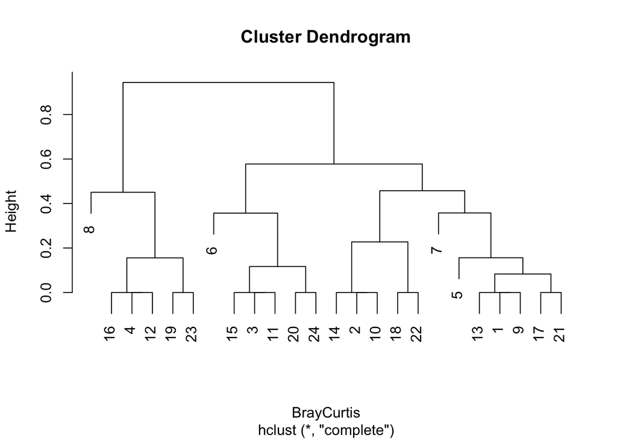

```r
hc<-hclust(BrayCurtis)
plot(hc,labels=dfTOTAL$rownames)
```

# Results

1. How many mice of each type, how many replicates of mouse x thymus x prep method.
2. Size of quadrat selected, and what this says about number of individual quadrats examined, number of total cell counts. People love those sorts of numbers!
3. Clustering and K selection
4. Using BC to validate how different clusters are, importance of composite versus individual layers.
5. Geography: Sornborger
6. etc.

# Discussion

To an extent, as K goes up it may be that spatial weighting is important, but we choose to avoid the problems that weighting brings up; it may also be possible that some of the areas defined as K approaches 10+ are legitimate microenvironments and this will be addressed in a later paper.

Literature Cited

Angelini, C., A. H. Altieri, B. R. Silliman, and M. D. Bertness. 2011. “Interactions Among Foundation Species and Their Consequences for Community Organization, Biodiversity, and Conservation.” Journal Article. *Bioscience* 61 (10): 782–89. doi:Doi 10.1525/Bio.2011.61.10.8. <Go to ISI>://WOS:000299805400008.

Verberk, W. 2011. “Explaining General Patterns in Species Abundance and Distributions.” Journal Article. *Nature Education Knowledge* 3: 38.